# Part II - Ford GoBike Exploration

## by Mohamed OLOU

## Investigation Overview

In this investigation, I wanted to look at the characteristics of trips that could be used to predict the distance of ride. The main focus was on 3 variables: duration, gender and age.

## Dataset Overview

This dataset includes information about 183412 individuals trips made in a bike-sharing system covering the greater San Francisco Bay Area. We have some variable like start and end longitude and latitude, the riding duration, the start and end station id, the user birth date, the user gender and the user type (suscriber or customer).

## Distribution of duration of riding

Ater investigation we find that generally cyclists ride between 300s and 500s. It takes on average between 5min and 8min. We might assume that users generally use bicycles for getting around and not for sports.

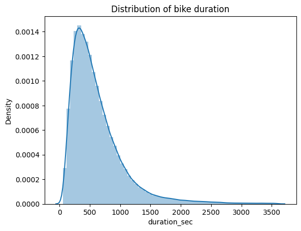

## Distibution of user's age

After exploration we remark that the most people that use those bike for a trip are between 26 and 36 year old.

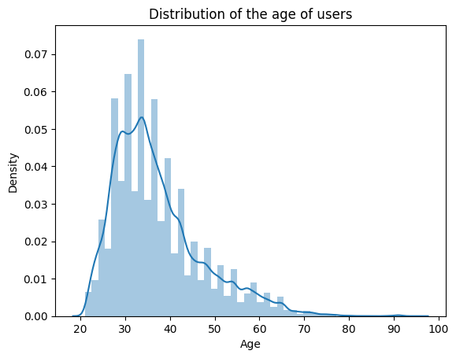

## Distibution of user's gender

We also remark that most of people that use those bike are man and the women are less than a third of men. After that we observe that few people are classified in other category.

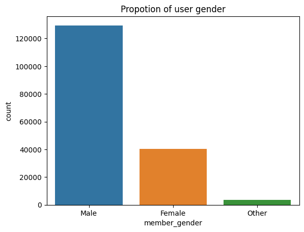

## Age VS Distance

Most of cyclists that ride are between 26 and 36 year old and ride on average 1.25 km

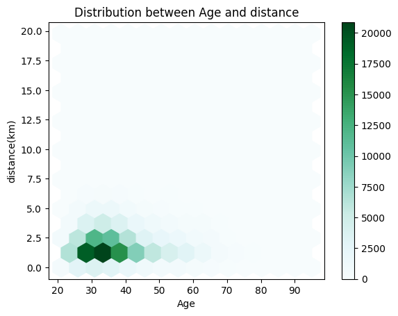